# Energy Efficiency Analysis

### Predicting Heating & Cooling Loads from Building Design Parameters

## 1. Introduction

This project analyzes the **UCI Energy Efficiency dataset**, which contains 768 simulated buildings with different architectural features.  
The goal is to:

- Understand how building design parameters impact **Heating Load** and **Cooling Load**.
- Build regression models to predict energy loads based on design choices.
- Demonstrate a full workflow from preprocessing -> EDA -> modeling -> evaluation.

## 2. Import Libraries

```python
import pandas as pd
import numpy as np

from sklearn.pipeline import Pipeline
from sklearn.preprocessing import StandardScaler, PolynomialFeatures
from sklearn.linear_model import LinearRegression, Ridge
from sklearn.metrics import mean_squared_error, r2_score
from sklearn.model_selection import cross_val_score, train_test_split

import seaborn as sns

import matplotlib.pyplot as plt
%matplotlib inline

# jupyter may require openpyxl explicitly installed to read excel files
!pip install openpyxl
```

## 3. Load Dataset

```python
# Loading the dataset
df = pd.read_excel('ENB2012_data.xlsx')

# Assigning readable column names
headers = ['Relative Compactness', 'Surface Area', 'Wall Area', 'Roof Area',
           'Overall Height', 'Orientation', 'Glazing Area', 'Glazing Area Distribution',
           'Heating Load', 'Cooling Load']

df.columns = headers
print(df.head(5))
```

```
   Relative Compactness  Surface Area  Wall Area  Roof Area  Overall Height  \
0                  0.98         514.5      294.0     110.25             7.0
1                  0.98         514.5      294.0     110.25             7.0
2                  0.98         514.5      294.0     110.25             7.0
3                  0.98         514.5      294.0     110.25             7.0
4                  0.90         563.5      318.5     122.50             7.0

   Orientation  Glazing Area  Glazing Area Distribution  Heating Load  \
0            2           0.0                          0         15.55
1            3           0.0                          0         15.55
2            4           0.0                          0         15.55
3            5           0.0                          0         15.55
4            2           0.0                          0         20.84

   Cooling Load
0         21.33
1         21.33
2         21.33
3         21.33
4         28.28
```

## 4. Data Overview

The dataset includes:

- **8 input features**.
- **2 target outputs**: Heating Load and Cooling Load.

```python
print(df.info())

print(df[['Orientation']].nunique())
print(df[['Glazing Area Distribution']].nunique())

print(df.describe())
```

```
<class 'pandas.core.frame.DataFrame'>
RangeIndex: 768 entries, 0 to 767
Data columns (total 10 columns):
 #   Column                     Non-Null Count  Dtype
---  ------                     --------------  -----
 0   Relative Compactness       768 non-null    float64
 1   Surface Area               768 non-null    float64
 2   Wall Area                  768 non-null    float64
 3   Roof Area                  768 non-null    float64
 4   Overall Height             768 non-null    float64
 5   Orientation                768 non-null    int64
 6   Glazing Area               768 non-null    float64
 7   Glazing Area Distribution  768 non-null    int64
 8   Heating Load               768 non-null    float64
 9   Cooling Load               768 non-null    float64
dtypes: float64(8), int64(2)
memory usage: 60.1 KB
None
Orientation    4
dtype: int64
Glazing Area Distribution    6
dtype: int64
       Relative Compactness  Surface Area   Wall Area   Roof Area  \
count            768.000000    768.000000  768.000000  768.000000
mean               0.764167    671.708333  318.500000  176.604167
std                0.105777     88.086116   43.626481   45.165950
min                0.620000    514.500000  245.000000  110.250000
25%                0.682500    606.375000  294.000000  140.875000
50%                0.750000    673.750000  318.500000  183.750000
75%                0.830000    741.125000  343.000000  220.500000
max                0.980000    808.500000  416.500000  220.500000

       Overall Height  Orientation  Glazing Area  Glazing Area Distribution  \
count       768.00000   768.000000    768.000000                  768.00000
mean          5.25000     3.500000      0.234375                    2.81250
std           1.75114     1.118763      0.133221                    1.55096
min           3.50000     2.000000      0.000000                    0.00000
25%           3.50000     2.750000      0.100000                    1.75000
50%           5.25000     3.500000      0.250000                    3.00000
75%           7.00000     4.250000      0.400000                    4.00000
max           7.00000     5.000000      0.400000                    5.00000

       Heating Load  Cooling Load
count    768.000000    768.000000
mean      22.307195     24.587760
std       10.090204      9.513306
min        6.010000     10.900000
25%       12.992500     15.620000
50%       18.950000     22.080000
75%       31.667500     33.132500
max       43.100000     48.030000
```

- Orientation and Glazing Area Distribution are integers AND have low unique values => both are categorical variables encoded by integers
- Continuous features (Surface Area, Wall Area, etc.) vary significantly in scale => needs normalization.

## 5. Data Preprocessing

```python
missing_data = df.isnull()
for column in missing_data.columns.values.tolist():
    print(missing_data[column].value_counts())
    print('')
```

```
Relative Compactness
False    768
Name: count, dtype: int64

Surface Area
False    768
Name: count, dtype: int64

Wall Area
False    768
Name: count, dtype: int64

Roof Area
False    768
Name: count, dtype: int64

Overall Height
False    768
Name: count, dtype: int64

Orientation
False    768
Name: count, dtype: int64

Glazing Area
False    768
Name: count, dtype: int64

Glazing Area Distribution
False    768
Name: count, dtype: int64

Heating Load
False    768
Name: count, dtype: int64

Cooling Load
False    768
Name: count, dtype: int64
```

- Absence of 'True'/null values affirms no missing values are present.
- I will also use specifications (https://archive.ics.uci.edu/dataset/242/energy+efficiency) to map label-encoded categorical variables to their corresponding names.

```python
orientation_map = {
    2: 'North',
    3: 'East',
    4: 'South',
    5: 'West'
}
df["Orientation"] = df["Orientation"].map(orientation_map)

glazing_map = {
    0: 'Uniform',
    1: 'North',
    2: 'East',
    3: 'South',
    4: 'West',
    5: 'Other'
}
df['Glazing Area Distribution'] = df['Glazing Area Distribution'].map(glazing_map)

print(df.head(5))
```

```
   Relative Compactness  Surface Area  Wall Area  Roof Area  Overall Height  \
0                  0.98         514.5      294.0     110.25             7.0
1                  0.98         514.5      294.0     110.25             7.0
2                  0.98         514.5      294.0     110.25             7.0
3                  0.98         514.5      294.0     110.25             7.0
4                  0.90         563.5      318.5     122.50             7.0

  Orientation  Glazing Area Glazing Area Distribution  Heating Load  \
0       North           0.0                   Uniform         15.55
1        East           0.0                   Uniform         15.55
2       South           0.0                   Uniform         15.55
3        West           0.0                   Uniform         15.55
4       North           0.0                   Uniform         20.84

   Cooling Load
0         21.33
1         21.33
2         21.33
3         21.33
4         28.28
```

## 6. Data Normalization

For all continuous variables, I will manually employ **Z-score normalization** due to large difference in scales.

```python
df['Relative Compactness'] = ( df['Relative Compactness'] - df['Relative Compactness'].mean() )/ df['Relative Compactness'].std()
df['Surface Area'] = ( df['Surface Area'] - df['Surface Area'].mean() )/ df['Surface Area'].std()
df['Wall Area'] = ( df['Wall Area'] - df['Wall Area'].mean() )/ df['Wall Area'].std()
df['Roof Area'] = ( df['Roof Area'] - df['Roof Area'].mean() )/ df['Roof Area'].std()
df['Overall Height'] = ( df['Overall Height'] - df['Overall Height'].mean() )/ df['Overall Height'].std()
df['Glazing Area'] = ( df['Glazing Area'] - df['Glazing Area'].mean() )/ df['Glazing Area'].std()

print(df.head(5))
```

```
   Relative Compactness  Surface Area  Wall Area  Roof Area  Overall Height  \
0              2.040447     -1.784712  -0.561586  -1.469119        0.999349
1              2.040447     -1.784712  -0.561586  -1.469119        0.999349
2              2.040447     -1.784712  -0.561586  -1.469119        0.999349
3              2.040447     -1.784712  -0.561586  -1.469119        0.999349
4              1.284142     -1.228438   0.000000  -1.197897        0.999349

  Orientation  Glazing Area Glazing Area Distribution  Heating Load  \
0       North       -1.7593                   Uniform         15.55
1        East       -1.7593                   Uniform         15.55
2       South       -1.7593                   Uniform         15.55
3        West       -1.7593                   Uniform         15.55
4       North       -1.7593                   Uniform         20.84

   Cooling Load
0         21.33
1         21.33
2         21.33
3         21.33
4         28.28
```

```python
# Select continuous variables you normalized
features_to_check = ["Relative Compactness", "Surface Area", "Wall Area",
                     "Roof Area", "Overall Height", "Glazing Area"]

# Check mean and std
print("Means after normalization:\n", df[features_to_check].mean().round(2))
print("\nStandard deviations after normalization:\n", df[features_to_check].std().round(2))
```

```
Means after normalization:
 Relative Compactness    0.0
Surface Area           -0.0
Wall Area               0.0
Roof Area               0.0
Overall Height          0.0
Glazing Area            0.0
dtype: float64

Standard deviations after normalization:
 Relative Compactness    1.0
Surface Area            1.0
Wall Area               1.0
Roof Area               1.0
Overall Height          1.0
Glazing Area            1.0
dtype: float64
```

## 6. Exploratory Data Analysis (EDA)

Before predicting energy loads on parameters, I will employ EDA-based plots to help answer the motivating question and truly understand how building design parameters impact Heating Load and Cooling Load.

To enable me to do this, I will employ tools to assess the most positively and/or negatively correlating **continuous** and **categorical** parameters on the target variables.

```python
df_numeric = df.select_dtypes(include=[np.number])
heating_corr = df_numeric.corr()["Heating Load"].sort_values(ascending=False)
cooling_corr = df_numeric.corr()["Cooling Load"].sort_values(ascending=False)
print(heating_corr)
print('')
print(cooling_corr)
```

```
Heating Load            1.000000
Cooling Load            0.975862
Overall Height          0.889430
Relative Compactness    0.622272
Wall Area               0.455671
Glazing Area            0.269842
Surface Area           -0.658120
Roof Area              -0.861828
Name: Heating Load, dtype: float64

Cooling Load            1.000000
Heating Load            0.975862
Overall Height          0.895785
Relative Compactness    0.634339
Wall Area               0.427117
Glazing Area            0.207505
Surface Area           -0.672999
Roof Area              -0.862547
Name: Cooling Load, dtype: float64
```

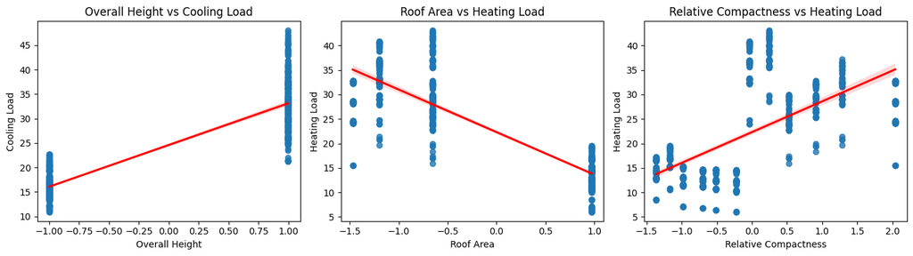

```python
plt.figure(figsize=(14,4))

# 1. Overall Height vs Cooling Load (strong +ve correlation)
plt.subplot(1,3,1)
sns.regplot(x="Overall Height", y="Cooling Load", data=df, line_kws={"color":"red"})
plt.title("Overall Height vs Cooling Load")

# 2. Roof Area vs Heating Load (strong -ve correlation)
plt.subplot(1,3,2)
sns.regplot(x="Roof Area", y="Heating Load", data=df, line_kws={"color":"red"})
plt.title("Roof Area vs Heating Load")

# 3. Relative Compactness vs Heating Load (moderate +ve correlation)
plt.subplot(1,3,3)
sns.regplot(x="Relative Compactness", y="Heating Load", data=df, line_kws={"color":"red"})
plt.title("Relative Compactness vs Heating Load")

plt.tight_layout()
plt.show()
```

**Note on Data Distribution:**  
The scatterplots above may appear unusual, as the predictor variables form discrete vertical bands rather than continuous spreads. This is expected for the UCI Energy Efficiency dataset, which is a synthetic dataset generated using EnergyPlus simulations.

Each building design parameters were simulated only at a small set of fixed levels. After Z-score normalization, these fixed levels collapse into distinct standardized values, producing the stacked vertical lines observed in the plots.

```python
df_test = df[ ['Orientation', 'Glazing Area Distribution',
               'Heating Load', 'Cooling Load']                 ]
df_grp = df_test.groupby(['Orientation', 'Glazing Area Distribution'], as_index=False).mean()
print(df_grp)
```

```
   Orientation Glazing Area Distribution  Heating Load  Cooling Load
0         East                      East     23.147778     24.172778
1         East                     North     23.216667     24.463889
2         East                     Other     22.721389     23.839722
3         East                     South     22.769444     24.975278
4         East                   Uniform     14.464167     18.941667
5         East                      West     22.686944     25.901389
6        North                      East     22.945833     25.378889
7        North                     North     22.943056     25.718611
8        North                     Other     22.817222     23.930278
9        North                     South     22.487500     25.431111
10       North                   Uniform     14.345833     20.280000
11       North                      West     23.026389     24.005278
12       South                      East     22.913611     24.289722
13       South                     North     23.138889     24.333056
14       South                     Other     22.405556     25.750556
15       South                     South     22.742222     24.152222
16       South                   Uniform     14.368000     18.920833
17       South                      West     22.729722     25.729167
18        West                      East     22.730556     26.146111
19        West                     North     22.805833     26.202500
20        West                     Other     22.779444     25.339444
21        West                     South     22.726667     24.079167
22        West                   Uniform     13.967500     20.682500
23        West                      West     23.103611     24.424722
```

A heatmap visualization (below) reinforces this result by clearly showing glazing distribution as the dominant categorical factor, while orientation has limited influence.

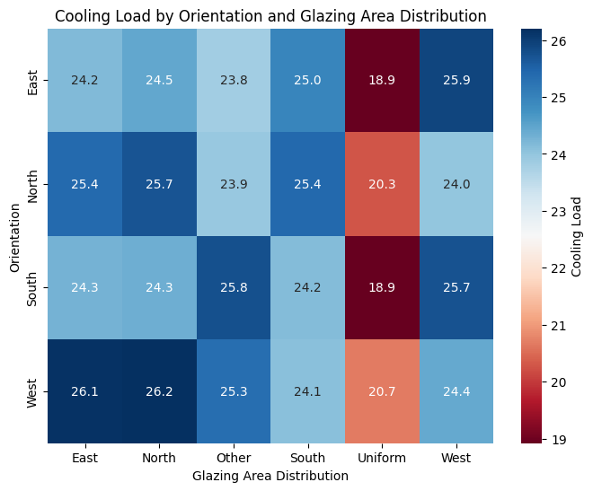

```python
cooling_pivot = df_grp.pivot(index='Orientation',
                             columns='Glazing Area Distribution',
                             values='Cooling Load')

plt.figure(figsize=(8,6))
sns.heatmap(cooling_pivot, annot=True, cmap='RdBu', fmt='.1f', cbar_kws={'label': 'Cooling Load'})
plt.title('Cooling Load by Orientation and Glazing Area Distribution')
plt.ylabel('Orientation')
plt.xlabel('Glazing Area Distribution')
plt.show()
```

### Transition to Modeling

From EDA, I conclude that:

- Among continuous variables, **Roof Area** and **Overall Height** have the strongest linear relationships with Heating and Cooling Loads, with Relative Compactness and Surface Area also showing moderate influence.
- Among categorical variables, **Glazing Area Distribution** strongly impacts energy loads, while Orientation has only a minor effect.

These findings motivate the next step: building regression models to predict Heating and Cooling Loads using these key predictors.

## 7. Regression Modeling

Having explored how building design parameters correlate with Heating and Cooling Loads, the next step is to develop predictive models. The aim of this section is to:

1. **Prediction:** Build regression models that can estimate Heating and Cooling Loads based on building design features.
2. **Interpretation:** Evaluate how well different types of regression (linear, polynomial and regularized) capture the underlying relationships identified during EDA.

To achieve this, I will implement the following models in sequence:

- **Simple Linear Regression** – using a single predictor to estimate Heating or Cooling Load.
- **Multiple Linear Regression** – combining several predictors for improved accuracy.
- **Polynomial Regression** – capturing potential non-linear effects.
- **Pipelines** – streamlining preprocessing and modeling into a reproducible workflow.

This staged approach will demonstrate how model complexity influences prediction accuracy, and provide insights into the trade-offs between simplicity, accuracy, and generalization.

### Simple Linear Regression

First, I will fit a simple linear regression model using a single predictor variable against a target variable. This provides a baseline and helps illustrate how one feature alone can predict Heating or Cooling Load.

```python
X = df[["Roof Area"]]
y = df["Heating Load"]

lr = LinearRegression()
lr.fit(X, y)

yhat = lr.predict(X)

print("Coefficient:", lr.coef_)
print("Intercept:", lr.intercept_)
```

```
Coefficient: [-8.69602083]
Intercept: 22.3071953125
```

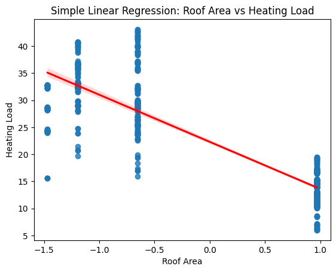

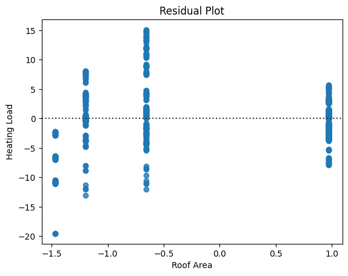

```python
# Regression plot
sns.regplot(x="Roof Area", y="Heating Load", data=df, line_kws={"color":"red"})
plt.title("Simple Linear Regression: Roof Area vs Heating Load")
plt.show()

# Residual plot
sns.residplot(x=X.squeeze(), y=y - yhat)
plt.title("Residual Plot")
plt.show()
```

### Multiple Linear Regression

Next, I use multiple predictors to estimate Heating Load. Multiple regression typically improves accuracy by accounting for multiple building parameters simultaneously.

```python
# Predictors and target
Z = df[["Relative Compactness", "Surface Area", "Wall Area", "Roof Area", "Overall Height", "Glazing Area"]]
Y = df["Heating Load"]

mlr = LinearRegression()
mlr.fit(Z, Y)

Yhat = mlr.predict(Z)

print("R²:", mlr.score(Z, Y))
```

```
R²: 0.9152588756036005
```

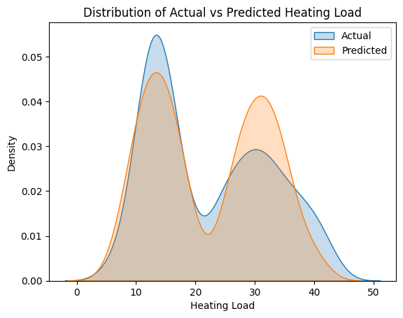

```python
sns.kdeplot(Y, label="Actual", fill=True)
sns.kdeplot(Yhat, label="Predicted", fill=True)
plt.title("Distribution of Actual vs Predicted Heating Load")
plt.legend()
plt.show()
```

### Polynomial Regression

To capture non-linear effects, I apply polynomial regression by transforming predictors into polynomial terms. This allows curvilinear relationships to be fitted while still using linear regression underneath.

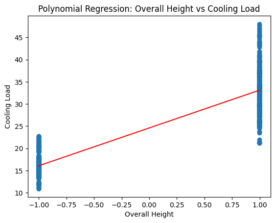

```python
X = df[["Overall Height"]]
Y = df["Cooling Load"]

poly = PolynomialFeatures(degree=2)
X_poly = poly.fit_transform(X)

pr = LinearRegression()
pr.fit(X_poly, Y)

Yhat_poly = pr.predict(X_poly)

plt.scatter(X, Y, label="Data")
plt.plot(np.sort(X, axis=0), Yhat_poly[np.argsort(X.values.flatten())], color="red")
plt.title("Polynomial Regression: Overall Height vs Cooling Load")
plt.xlabel("Overall Height")
plt.ylabel("Cooling Load")
plt.show()
```

### Pipelines

Finally, I use a pipeline to combine preprocessing (scaling, polynomial transformation) with regression into one clean workflow. Pipelines simplify code and prevent data leakage.

```python
X = df[["Relative Compactness", "Surface Area", "Wall Area", "Roof Area", "Overall Height", "Glazing Area"]]
Y = df["Heating Load"]

pipe = Pipeline([
    ("scale", StandardScaler()),
    ("poly", PolynomialFeatures(degree=2)),
    ("model", LinearRegression())
])

pipe.fit(X, Y)
Yhat_pipe = pipe.predict(X)

print("Pipeline R²:", pipe.score(X, Y))
```

```
Pipeline R²: 0.9921524285789026
```

```
Pipeline R²: 0.9921524285789026
Pipeline MSE: 0.7979383010875948
```

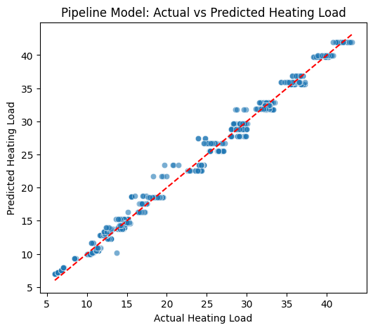

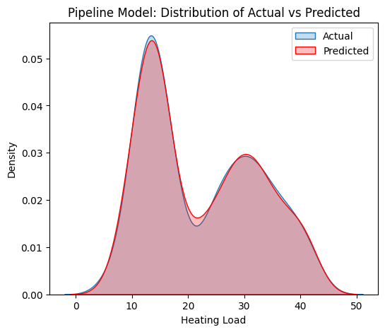

```python
X = df[["Relative Compactness", "Surface Area", "Wall Area",
        "Roof Area", "Overall Height", "Glazing Area"]]
Y = df["Heating Load"]

# Build pipeline: scaling + polynomial transform + regression
pipe = Pipeline([
    ("scale", StandardScaler()),
    ("poly", PolynomialFeatures(degree=2)),
    ("model", LinearRegression())
])

# Fit pipeline
pipe.fit(X, Y)
Yhat_pipe = pipe.predict(X)

# Evaluation
print("Pipeline R²:", r2_score(Y, Yhat_pipe))
print("Pipeline MSE:", mean_squared_error(Y, Yhat_pipe))

# --- Plot 1: Actual vs Predicted (Scatter) ---
plt.figure(figsize=(6,5))
sns.scatterplot(x=Y, y=Yhat_pipe, alpha=0.6)
plt.plot([Y.min(), Y.max()], [Y.min(), Y.max()], 'r--')  # 45° reference line
plt.xlabel("Actual Heating Load")
plt.ylabel("Predicted Heating Load")
plt.title("Pipeline Model: Actual vs Predicted Heating Load")
plt.show()

# --- Plot 2: Distribution Plot ---
plt.figure(figsize=(6,5))
sns.kdeplot(Y, label="Actual", fill=True)
sns.kdeplot(Yhat_pipe, label="Predicted", fill=True, color="red")
plt.title("Pipeline Model: Distribution of Actual vs Predicted")
plt.legend()
plt.show()
```

## 8. Model Evaluation

After fitting regression models, the final step is to evaluate their accuracy, stability, and generalization. Evaluation helps compare models and ensures predictions are not only accurate on training data but also robust on unseen data.

I will evaluate models using the following steps:

- **Metrics (R², MSE):** Quantify accuracy on training/test sets.
- **Cross-Validation:** Assess stability across different folds.
- **Overfitting Check:** Compare train vs test error as model complexity increases.
- **Ridge Regression:** Apply regularization to improve generalization.

### Metrics: R² and MSE

First, I split the dataset into training and testing subsets. R² and Mean Squared Error (MSE) are used to compare predictions with true values.

```python
X = df[["Relative Compactness", "Surface Area", "Wall Area", "Roof Area", "Overall Height", "Glazing Area"]]
Y = df["Heating Load"]

X_train, X_test, y_train, y_test = train_test_split(X, Y, test_size=0.2, random_state=1)

mlr = LinearRegression()
mlr.fit(X_train, y_train)

yhat_train = mlr.predict(X_train)
yhat_test = mlr.predict(X_test)

print("Training R²:", r2_score(y_train, yhat_train))
print("Test R²:", r2_score(y_test, yhat_test))
print("Test MSE:", mean_squared_error(y_test, yhat_test))
```

```
Training R²: 0.9188838205625396
Test R²: 0.8991531479435912
Test MSE: 10.13406316839338
```

### Cross-Validation

To test stability, I apply k-fold cross-validation. This evaluates model performance across multiple folds rather than a single train/test split.

```python
scores = cross_val_score(mlr, X, Y, cv=5, scoring="r2")
print("Cross-validation R² scores:", scores)
print("Mean CV R²:", scores.mean())
```

```
Cross-validation R² scores: [0.81027769 0.88908004 0.92511778 0.9295018  0.92120944]
Mean CV R²: 0.8950373501719291
```

### Overfitting Check

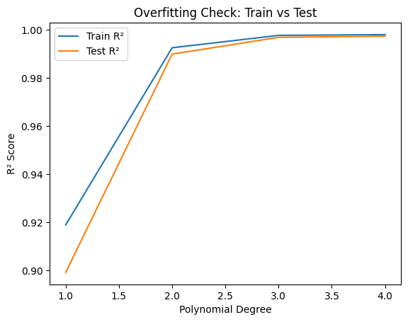

```python
train_scores = []
test_scores = []
degrees = [1, 2, 3, 4]

for d in degrees:
    poly = PolynomialFeatures(degree=d)
    X_poly = poly.fit_transform(X_train)
    X_poly_test = poly.transform(X_test)

    lr = LinearRegression().fit(X_poly, y_train)

    train_scores.append(lr.score(X_poly, y_train))
    test_scores.append(lr.score(X_poly_test, y_test))

plt.plot(degrees, train_scores, label="Train R²")
plt.plot(degrees, test_scores, label="Test R²")
plt.xlabel("Polynomial Degree")
plt.ylabel("R² Score")
plt.title("Overfitting Check: Train vs Test")
plt.legend()
plt.show()
```

### Ridge Regression

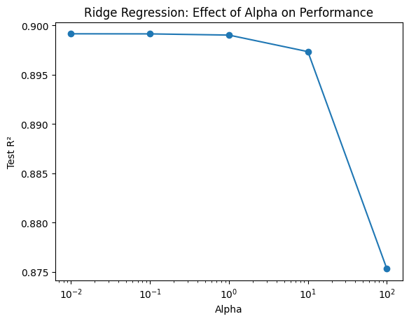

```python
from sklearn.linear_model import Ridge

alphas = [0.01, 0.1, 1, 10, 100]
ridge_scores = []

for a in alphas:
    ridge = Ridge(alpha=a)
    ridge.fit(X_train, y_train)
    ridge_scores.append(ridge.score(X_test, y_test))

plt.plot(alphas, ridge_scores, marker="o")
plt.xscale("log")
plt.xlabel("Alpha")
plt.ylabel("Test R²")
plt.title("Ridge Regression: Effect of Alpha on Performance")
plt.show()
```

### Summary

This concludes the full workflow: preprocessing → EDA → modeling → evaluation. The results demonstrate that building design parameters (especially Roof Area, Overall Height, and Glazing Distribution) are strong predictors of Heating and Cooling Loads, and that regression models can effectively capture these relationships.